# Examen 1 Metodos de Regresion

#### Datos del Autor:

Presentado por: Yosef Shmuel Guevara Salamanca

Codigo: 1014236208

#### Examen 1

NOTA: LOS PUNTOS 1 al 4 deben desarrollarse escogiendo variables apropiadas de una de dos bases de Datos: a) Tallas.babies (ver datos en este correo), o b) de la base de Datos mtcars del software R, usando las covariables wt, disp y hp. (Use un error tipo I de 0.10 donde se requiera).

#### Librerias

```r
# Cargan librerias necesarias examen


library(MASS)
library(MVN)
library(MASS)
library(lmtest)
library(nortest)
```

#### DataFrame

```r
data("mtcars")
attach(mtcars)
head(mtcars)
```

|  | mpg | cyl | disp | hp | drat | wt | qsec | vs | am | gear | carb |
| --- | --- | --- | --- | --- | --- | --- | --- | --- | --- | --- | --- |
| Mazda RX4 | 21.0 | 6 | 160 | 110 | 3.90 | 2.620 | 16.46 | 0 | 1 | 4 | 4 |
| Mazda RX4 Wag | 21.0 | 6 | 160 | 110 | 3.90 | 2.875 | 17.02 | 0 | 1 | 4 | 4 |
| Datsun 710 | 22.8 | 4 | 108 | 93 | 3.85 | 2.320 | 18.61 | 1 | 1 | 4 | 1 |
| Hornet 4 Drive | 21.4 | 6 | 258 | 110 | 3.08 | 3.215 | 19.44 | 1 | 0 | 3 | 1 |
| Hornet Sportabout | 18.7 | 8 | 360 | 175 | 3.15 | 3.440 | 17.02 | 0 | 0 | 3 | 2 |
| Valiant | 18.1 | 6 | 225 | 105 | 2.76 | 3.460 | 20.22 | 1 | 0 | 3 | 1 |

#### Punto 1

1. (Valor 1.0) Con base en los conceptos del curso, ilustre con un ejemplo completo el coeficiente de correlaci ́on de Pearson.

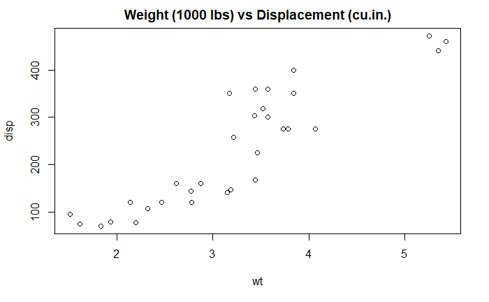

```r
# se seleccionan las variables a analizar

plot(wt, disp, main="Weight (1000 lbs) vs Displacement (cu.in.)")
```

```r
NA
NA
```

```r
#### Se realiza el test de mardia (mvn)

mvn(data.frame(wt,disp))
```

| Test | Statistic | p value | Result |
| --- | --- | --- | --- |
| Mardia Skewness | 2.19799093675657 | 0.69939710999255 | YES |
| Mardia Kurtosis | -1.17737535488371 | 0.239045722115849 | YES |
| MVN | NA | NA | YES |

|  | Test | Variable | Statistic | p value | Normality |
| --- | --- | --- | --- | --- | --- |
| 1 | Shapiro-Wilk | wt | 0.9433 | 0.0927 | YES |
| 2 | Shapiro-Wilk | disp | 0.9200 | 0.0208 | NO |

|  | n | Mean | Std.Dev | Median | Min | Max | 25th | 75th | Skew | Kurtosis |
| --- | --- | --- | --- | --- | --- | --- | --- | --- | --- | --- |
| wt | 32 | 3.21725 | 0.9784574 | 3.325 | 1.513 | 5.424 | 2.58125 | 3.61 | 0.4231465 | -0.02271075 |
| disp | 32 | 230.72188 | 123.9386938 | 196.300 | 71.100 | 472.000 | 120.82500 | 326.00 | 0.3816570 | -1.20721195 |

```
NA
```

Gracias a la prueba de mardia podemos decir que existe una normalidad bivariada tal como lo confirma el test de Mardia, pues no se rechaza Ho, por ende se procede a utilizar el estimador de pearson, es decir si hay normal multivariada

p_value: 0.6993(Skewness) and 0.2390(Kurtosis)

```r
#### Se realiza el test de mardia (mvn)

cor.test(wt,disp, method = "pearson")
```

```
    Pearson's product-moment correlation

data:  wt and disp
t = 10.576, df = 30, p-value = 1.222e-11
alternative hypothesis: true correlation is not equal to 0
95 percent confidence interval:
 0.7811586 0.9442902
sample estimates:
      cor
0.8879799
```

se rechaza Ho pues p-value = 1.222e-11, El estimador de Pearson es r= 0.88, esdecir que existe una asociacion lineal positiva significativa entre Weight y el desplazamiento

#### Punto 2

2. (Valor 1.0) Con base en los conceptos del curso, ilustre con un ejemplo completo el coeficiente de correlacíon de Spearman.

[figure not shown]

```r
plot(mtcars$wt, mtcars$hpr, main="Weight (1000 lbs) vs Gross horsepower")
```

#### Se realiza el test de mardia(mvn)

```r
mvn(data.frame(mtcars$wt,mtcars$hp))
```

| Test | Statistic | p value | Result |
| --- | --- | --- | --- |
| Mardia Skewness | 16.4195205314786 | 0.00250492509875378 | NO |
| Mardia Kurtosis | 1.2110638887512 | 0.225870919893391 | YES |
| MVN | NA | NA | NO |

|  | Test | Variable | Statistic | p value | Normality |
| --- | --- | --- | --- | --- | --- |
| 1 | Shapiro-Wilk | mtcars.wt | 0.9433 | 0.0927 | YES |
| 2 | Shapiro-Wilk | mtcars.hp | 0.9334 | 0.0488 | NO |

|  | n | Mean | Std.Dev | Median | Min | Max | 25th | 75th | Skew | Kurtosis |
| --- | --- | --- | --- | --- | --- | --- | --- | --- | --- | --- |
| mtcars.wt | 32 | 3.21725 | 0.9784574 | 3.325 | 1.513 | 5.424 | 2.58125 | 3.61 | 0.4231465 | -0.02271075 |
| mtcars.hp | 32 | 146.68750 | 68.5628685 | 123.000 | 52.000 | 335.000 | 96.50000 | 180.00 | 0.7260237 | -0.13555112 |

```
NA
```

Usando el test de Mardia podemos decir que no existe normalidad bivariada, con un valor p de 0.0025(Skweness) y un valor.p=0.22 (kutosis), por ende es necesario usar Spearman, pues se rechaza Ho

```r
cor.test(mtcars$wt,mtcars$hp, method = "spearman")
```

```
Cannot compute exact p-value with ties
```

```
    Spearman's rank correlation rho

data:  mtcars$wt and mtcars$hp
S = 1229.4, p-value = 1.954e-07
alternative hypothesis: true rho is not equal to 0
sample estimates:
      rho
0.7746767
```

Se rechaza Ho, es decir que rho es diferentes de 0, pues p-value = 1.954e-07.

El estimador spearman rs = 0.77, es decir que existe una asociacion lineal, significativa, entre Weight y el Gross horsePower

#### Punto 3

3. (Valor 1.0) Con base en los conceptos del curso, ilustre un ejemplo completo de Regresi ́on Lineal Simple (RLS) en el que tenga sentido interpretar la pendiente estimada.

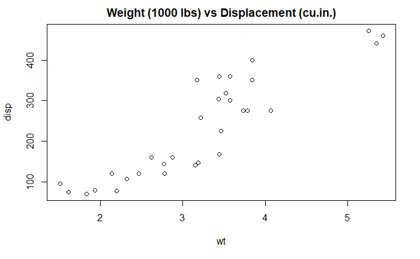

```r
plot(wt, disp, main="Weight (1000 lbs) vs Displacement (cu.in.)")
```

```r
Fitt_WvD <- lm(disp ~ wt)
summary(Fitt_WvD)
```

```
Call:
lm(formula = disp ~ wt)

Residuals:
   Min     1Q Median     3Q    Max
-88.18 -33.62 -10.05  35.15 125.59

Coefficients:
            Estimate Std. Error t value Pr(>|t|)
(Intercept)  -131.15      35.72  -3.672 0.000933 ***
wt            112.48      10.64  10.576 1.22e-11 ***
---
Signif. codes:  0 ‘***’ 0.001 ‘**’ 0.01 ‘*’ 0.05 ‘.’ 0.1 ‘ ’ 1

Residual standard error: 57.94 on 30 degrees of freedom
Multiple R-squared:  0.7885,    Adjusted R-squared:  0.7815
F-statistic: 111.8 on 1 and 30 DF,  p-value: 1.222e-11
```

#### COMIENZO A VALIDAR SUPUESTOS.

###### Validacion de normalidad

```r
shapiro.test(Fitt_WvD$residuals)
```

```
    Shapiro-Wilk normality test

data:  Fitt_WvD$residuals
W = 0.96071, p-value = 0.2872
```

p-value = 0.2872 no se rechaza Ho,existe de una distribucion normal

```r
lillie.test(Fitt_WvD$residuals)
```

```
    Lilliefors
    (Kolmogorov-Smirnov) normality
    test

data:  Fitt_WvD$residuals
D = 0.11854, p-value = 0.3024
```

p-value = 0.3024 no se rechaza Ho, existe una distribucion normal

#### Analisis de Varianza cte.

```r
bptest(disp~ wt)
```

```
    studentized Breusch-Pagan test

data:  disp ~ wt
BP = 0.26991, df = 1, p-value = 0.6034
```

p-value = 0.6034, No se rechaza Ho, exsite una varianza constante.

```r
gqtest(lm(disp~ wt))
```

```
    Goldfeld-Quandt test

data:  lm(disp ~ wt)
GQ = 0.80881, df1 = 14, df2 = 14, p-value = 0.6516
alternative hypothesis: variance increases from segment 1 to 2
```

p-value = 0.6516, No se rechaza Ho, exsite una varianza constante.

#### Independencia

```r
dwtest(disp ~ Fitt_WvD$residuals)
```

```
    Durbin-Watson test

data:  disp ~ Fitt_WvD$residuals
DW = 0.82199, p-value = 6.993e-05
alternative hypothesis: true autocorrelation is greater than 0
```

4. (Valor 1.0) Escoja un modelo de RLS apropiado para ilustrar el c ́alculo de un inter- valo de predicci ́on del 90 % para la variable respuesta cuando la covariable toma el

valor de su promedio, x.